# PanelContainer

# PanelContainer and MarginContainer maximize Control nodes

`PanelContainer` provides a background for child `Control` nodes. `MarginContainer` provides padding around the edges.

Both nodes are very similar in that they maximize their `Control` children’s sizes, making them useful as root nodes for UI scenes.

In this guide, you will learn:

- The differences between `PanelContainer` and `MarginContainer`.
- The benefits of `MarginContainer` as a root scene.
- How to create a drag and drop inventory.
- How to build trading cards out of `Control` nodes.

Contents:

- PanelContainer and MarginContainer’s key features
  - Maximize Control children
  - Put Control children on the edges and corners
  - Change appearance using StyleBoxes
  - Report when the children have changed
- How to use a PanelContainer and MarginContainer in practice
  - Fit a dynamic speech bubble to dialogue
  - Draw a border and shadow around a card
  - Hold icons in a drag and drop inventory
  - Fit children when resizing the window
- Your questions
  - How do I change the background on a PanelContainer?
  - How do I add or remove margins on a PanelContainer?
  - How do I move child nodes inside a PanelContainer?
  - What are the differences between Panel, MarginContainer, and PanelContainer?

## PanelContainer and MarginContainer’s key features

All the following key features and use cases apply to both nodes. We primarily use `PanelContainer` because it’s easier to see its placement in these scenes.

### Maximize Control children

A `Container` node handles the position and size of its `Control` children automatically. Add a child to a `PanelContainer`, and it automatically expands to fit the `PanelContainer`’s size.

If you want to split the `PanelContainer` for other children to use, add a `VBoxContainer` or `HBoxContainer`, and place your control children in those nodes. You can read more in the HBoxContainer guide.

This is true for the `MarginContainer` as well, except it’s transparent, and *Custom Constants -> Margin* adjusts its margins.

### Put Control children on the edges and corners

Although the general purpose of a `PanelContainer` is to expand its children, you can position a child on the edges and corners of a `PanelContainer` by adjusting the child’s *Size Flags*.

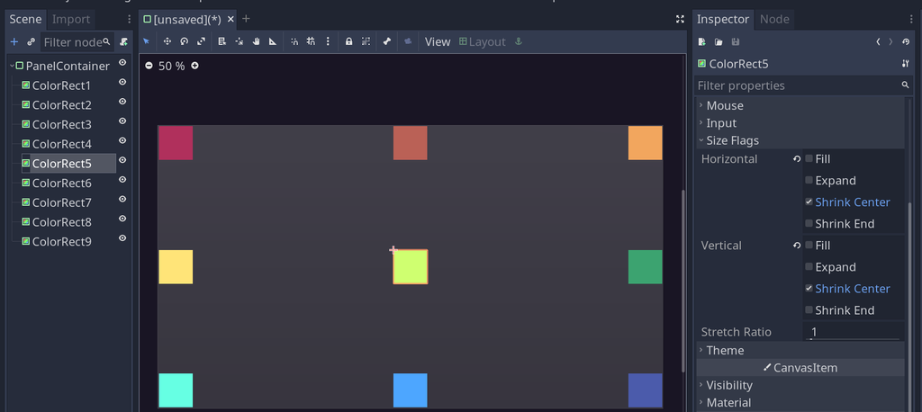

You can learn more about size flags by reading the HBoxContainer guide.

You can’t use the *Expand* size flag on children of a `PanelContainer` because all children extend their bounding box to fit up all the available space. *Fill*, *Shrink End*, and *Shrink Center* change the size and positions of the node accordingly.

Although the *Anchor* properties in all `Control` nodes do something similar, *Anchors* do not work inside containers. They are better suited for loose `Control` nodes.

### Change appearance using StyleBoxes

You can change the appearance of a `PanelContainer` by editing the *Custom Styles -> Panel* property. Here are some options to choose from when styling a `PanelContainer`:

- `StyleBoxEmpty` makes the `PanelContainer` transparent. This makes it look like a default `MarginContainer`.
- `StyleBoxFlat` creates a colored background and border. You can adjust the border’s thickness, give its corners rounded edges, and add a shadow to the style box.
- `StyleBoxTexture` lets you style your `PanelContainer` with a nine-patch texture.
- `StyleBoxLine` creates a thin line that scales in one direction. The `HSeparator` and `VSeparator` nodes use this resource.

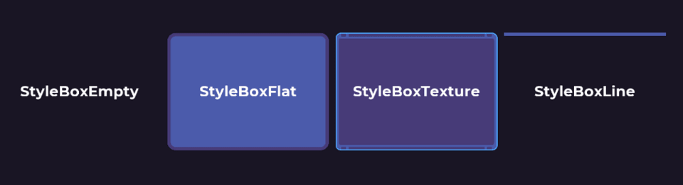

### Report when the children have changed

The `sort_children` signal emits when a child is added or removed to the `PanelContainer`.

Normally, a `PanelContainer` grows to fit any growing `Control` children. However, the `PanelContainer` won’t shrink to fit a shrinking child node. We can shrink the `PanelContainer` back to fit the new child size using the `sort_children` signal because it emits when the child changes its size. We’ll see this in action when we cover dynamic speech bubbles that fit dialogue.

## How to use a PanelContainer and MarginContainer in practice

Here are some real-world use cases for `PanelContainer` and `MarginContainer`.

### Fit a dynamic speech bubble to dialogue

Some games with dialogue choose to present dialogue as a speech bubble which fits the length of the text. Games like *Oxenfree* and *Night in the Woods* use this effect.

[figure not shown]

*Game: Night in the Woods (2017)*

You can achieve this using a `PanelContainer` with a `Label` child.

Here is the way we set this speech bubble up:

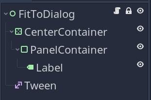

In our implementation, we used a `CenterContainer` to center the bubble on the screen. You can move the `CenterContainer` to move the speech bubble elsewhere.

To set the speech bubble up, we need some dialogue.

```
extends Node2D

## Display speed of the text in characters per second.
const TEXT_DISPLAY_SPEED := 50.0
const LINES = [
    "What does all this do? I don't trust it,\ndon't touch anything.",
    "I found it! There's something under here!",
    "Ugh...\nso bored...help me...",
    "Thanks for the help!",
    "You go on ahead, I'll hang back in case the others show up.",
    "Wait...\nAre you really sure about that?",
]

onready var _label: Label = $CenterContainer/PanelContainer/Label
onready var _tween: Tween = $Tween
```

Now, we need a function to animate the `Label`’s *Percent Visible* property. The `Label`’s size won’t change, but the text will show itself gradually as we increase *Percent Visible*.

We use a `Tween` to adjust *Percent Visible* because it gives us more control over how fast the text appears.

The `Tween` duration is `len(_label.text) / TEXT_DISPLAY_SPEED`. In this equation, we make the duration of the animation proportional to the number of characters. Each character in the `Label` should appear at regular intervals. We can then speed up or slow down the animation by altering the text display speed constant.

```
func _play_dialog() -> void:
    _label.text = LINES.front()
    # We cycle lines of text in the array.
    LINES.push_back(LINES.pop_front())
    _tween.interpolate_property(
        _label, "percent_visible", 0.0, 1.0, len(_label.text) / TEXT_DISPLAY_SPEED
    )
    _tween.start()
```

We could instead reveal text by animating the *Visible Characters* property every frame, but this risks making the dialogue framerate dependent without more code.

Lastly, we tie this input to the player’s “interact” action.

```
func _unhandled_input(event: InputEvent) -> void:
    if event.is_action_pressed("interact"):
        _play_dialog()
```

Grow *Direction -> Both* makes the dialogue bubble expand in the middle.

We used `CenterContainer` to make it clear that the dialogue bubble should remain centered, but using the *Grow Direction -> Both* setting works the same in this case. We’d recommend using `CenterContainer` if you want to move the speech bubble but still keep it centered to a specific area.

### Draw a border and shadow around a card

When creating a card game in Godot, you may want to draw an outline around a `Control` node or adding a drop shadow to it.

A `PanelContainer` shines in this regard because it’s easier to use than `MarginContainer`.

Shadows can add a lot of depth to your user interfaces, especially when multiple elements are moving around.

In this situation, `PanelContainer` is useful because it fits around its child `Control` nodes and can draw a `StyleBox` behind them with this outline and drop shadow.

We can create cards for a card game using a `PanelContainer` to draw the border around the card and the drop shadow indicating its height.

The card has a `PanelContainer` for the background with a `VBoxContainer` to sort its contents.

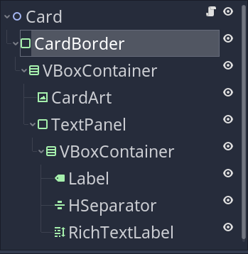

For the `PanelContainer`, we can add a new `StyleBox` with *Border Width*, *Border Color*, *Corner Radius* for rounding the corners, and a *Shadow*.

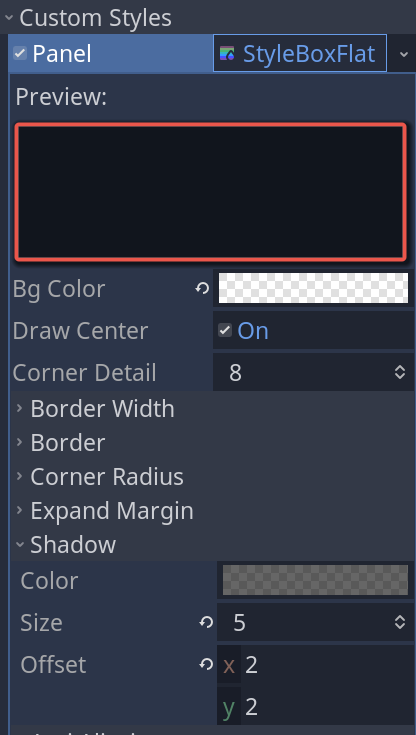

If the contents of our card increase or decrease in size, our `PanelContainer` automatically surrounds it with our nicely styled border and shadow. Because of the margin of our `PanelContainer`, the contents can’t overlap the border at all.

A fantastic resource to learn more about using shadows in user interface design is [Google’s material design documentation](https://material.io/design/environment/light-shadows.html#shadows).

### Hold icons in a drag and drop inventory

A drag and drop inventory is a common feature in games like *Minecraft* and *Diablo*.

[figure not shown]

*Game: Minecraft (2011)*

Although it takes multiple nodes to create, a `PanelContainer`’s role is to provide a background and expand the items in the inventory.

Our goal is to make an inventory that can move items between slots and swap items between slots.

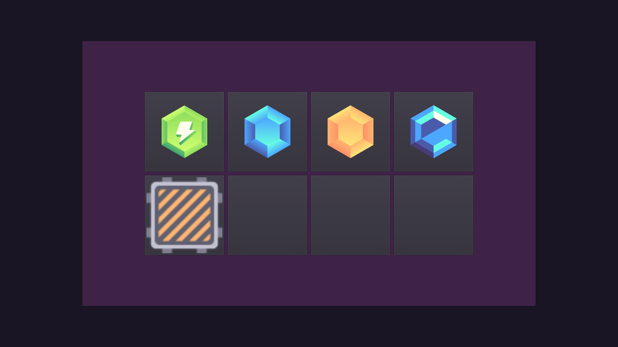

Godot has three useful methods to drag and drop data between `Control` nodes: `get_drag_data()`, `can_drop_data()` and `drop_data()`. Here’s what calls these methods:

- Clicking and holding on a node calls `get_drag_data()`.
- Dragging your mouse over another node calls `can_drop_data()`.
- Releasing your mouse over another node calls `drop_data()`.

These methods must be overwritten as functions in a script to enable the drag and drop functionality. `get_drag_data()` should return a value (like a texture or a `String`) for the target node to receive. `can_drop_data()` should return `true` or `false` to determine if the target node is valid or not.

There’s a problem with these methods, though. Their behavior works fine for moving data, but it’s not naturally equipped to swap data. Any attempts to swap data only overwrites the dropped slot’s data. You can see this limitation in the [official Godot demo for drag and drop.](https://godotengine.org/asset-library/asset/133)

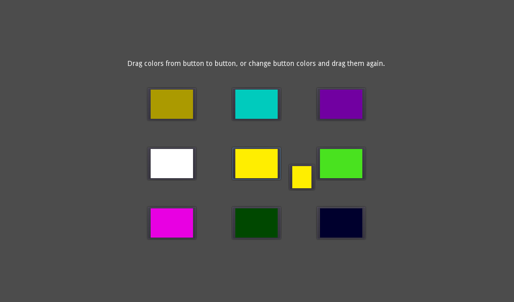

We use drag forwarding to solve this.

When a `Control` node has drag forwarding enabled, it calls the drag and drop functions of a target node instead of its own.

This way, we only need a single parent script. All inventory slots can have `set_drag_forwarding(self)` called on them from our parent script, which sends their method calls to our one script.

Drag forwarding is necessary because it reports the involved `Control` nodes in every method call. It’s like reporting physics bodies in an `Area2D` using `body_entered`. This lets us swap data to the last `Control` node we dragged if we end up overwriting existing data.

Here’s the setup for our scene:

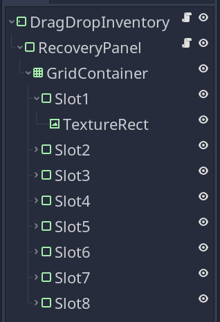

A `PanelContainer` called *RecoveryPanel* is the parent of our `GridContainer` with `PanelContainer` slots. This is one way to preserve data that is accidentally dropped outside of a valid drop target. By default, we lose data dropped outside of a valid drop target, so this panel catches it and returns it to the parent script using a signal.

```
extends Control

# We store a reference to the previously dragged item when swapping it with
# another.
var _last_dragged_item: TextureRect

onready var _grid: GridContainer = $RecoveryPanel/GridContainer
onready var _recovery_panel: PanelContainer = $RecoveryPanel


func _ready() -> void:
    # First, we find all the draggable items in the inventory.
    var texture_rects := []
    for item_slot in _grid.get_children():
        for item in item_slot.get_children():
            if item is TextureRect:
                texture_rects.append(item)

    # We then redirect calls from the children's drag and drop functions to this
    # script.
    for item in texture_rects:
        item.set_drag_forwarding(self)

    # We use a panel in the background to detect when the player drags an item
    # away from the inventory slots.
    _recovery_panel.connect(
        "data_recovered", self, "_on_RecoveryPanel_data_recovered"
    )
```

Before getting into the drag and drop method calls, we need to see what we’re dragging. We can make a function that creates a `TextureRect` using a texture. We’ll later use this function to send a `TextureRect` to the built-in `set_drag_preview()` function, which attaches an image of the data to our mouse cursor.

```
# Creates a smaller preview image to display when calling set_drag_preview()
func make_preview(texture: Texture) -> TextureRect:
    var preview := TextureRect.new()
    preview.rect_size = Vector2(64, 64)
    preview.texture = texture
    preview.expand = true
    preview.stretch_mode = TextureRect.STRETCH_KEEP_ASPECT
    return preview
```

Now that everything’s set up, let’s write our drag and drop methods.

`drag_data_fw()` gets the texture of the `Control` node we dragged from and makes a preview of it. This texture is also returned so Godot can give it to the node accessed in `drop_data_fw()`.

Our `_last_dragged_item` variable is the `Control` node we just clicked. This is important to know which slot should get an item back if we swap items or drop our data outside a valid slot by accident.

```
func get_drag_data_fw(_position: Vector2, source_control: Control) -> Texture:
    _last_dragged_item = source_control

    var _texture: Texture = source_control.texture
    source_control.texture = null
    set_drag_preview(make_preview(_texture))
    # We return the texture so it'll become the `dragged_texture` in
    # can_drop_data_fw() and drop_data_fw().
    return _texture
```

Next, we need to see if there is any data to drop. If what we grabbed was `null`, from an empty slot, then we don’t want to replace any textures with it.

```
func can_drop_data_fw(
    _position: Vector2, dragged_texture: Texture, _target_control: Control
) -> bool:
    # We check that dragged data exists to prevent us from overwriting a slot with null.
    return dragged_texture != null
```

We now need two pieces of functionality in our drop function: the ability to drop textures onto a slot with `null` data, and the ability to swap two textures.

```
func drop_data_fw(_position: Vector2, dragged_texture: Texture, new_slot: Control) -> void:
    var new_texture: Texture = new_slot.texture
    # If the target slot is empty, we assign the dragged texture to it.
    if new_texture == null:
        new_slot.texture = dragged_texture
    # If the target slot contains something,
    else:
        var data_to_replace: Texture = new_slot.texture
        _last_dragged_item.texture = data_to_replace
        new_slot.texture = dragged_texture
```

Last for this script is to create a callback function for another script on the *RecoveryPanel*. This panel retrieves any data dropped outside of a slot. We can retrieve the reference to the last `Control` node data we grabbed and give it back to the `Control` node.

```
func _on_RecoveryPanel_data_recovered(data: Texture) -> void:
    # Any data dropped on the panel behind the grid is returned here, and set as
    # the last dragged item's texture.
    _last_dragged_item.texture = data
```

With our *DragDropInventory* script done, the last step is to create another script on the `PanelContainer` sitting behind the inventory. This node accepts any data that was accidentally dropped outside of the inventory slots.

It first needs a signal to send back to the inventory, which we declare with an argument that contains the dropped texture.

```
extends PanelContainer

signal data_recovered(texture)
```

We use the regular `can_drop_data()` and `drop_data()` functions since this isn’t forwarding all slots to one script. This is its own script that uses a regular signal to send data.

```
func can_drop_data(_position: Vector2, dragged_texture: Texture) -> bool:
    return dragged_texture != null


func drop_data(_position: Vector2, dragged_texture: Texture) -> void:
    emit_signal("data_recovered", dragged_texture)
```

When you have `Control` nodes of multiple sizes, a `PanelContainer` is a great way to make sure they grow to make use of the space they’re given.

The end result is a flexible system that uses native drag and drop functions found in all `Control` nodes.

### Fit children when resizing the window

A common issue with user interfaces in Godot is making them fit the game window while resizing.

With Godot’s many tools and options for UI positioning and scaling, it can be difficult to ensure all `Control` nodes stay on-screen no matter the resolution.

One way to address this is to use a `MarginContainer` as your scene root. You can set its *Anchor* preset to *Full Rect*, so `Control` children fill your entire screen space. The `HBoxContainer` and `VBoxContainer` nodes can serve as dividers to automatically position and scale other `Control` nodes.

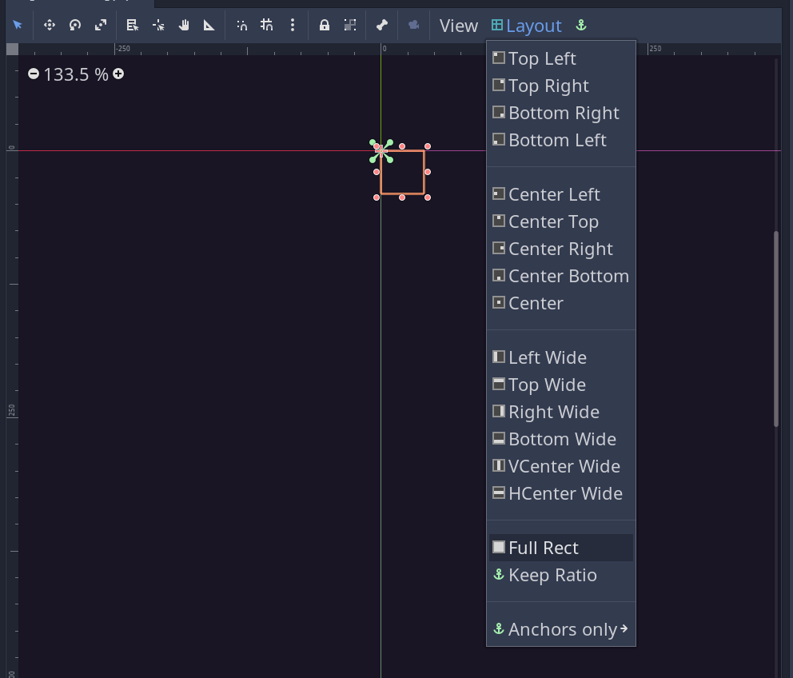

You can do this with a `PanelContainer` as well, although the `StyleBox` your `PanelContainer` is using may cover the screen.

`MarginContainer` is ideal for fitting UI over the game world and displaying a HUD. It’s transparent and doesn’t obstruct vision. The *Custom Constants -> Margin* properties let you add space between the edge of the screen and the UI. Using margins is a way to give your UI more breathing room.

For UI systems that aim for a decoupled, instanced scene approach, `PanelContainer` makes for a great scene root. If you prefer the background to be partially transparent, you can adjust the `StyleBox` or the *UI Theme* to let you see more information behind the UI.

## Your questions

### How do I change the background on a PanelContainer?

You can change the appearance of a `PanelContainer` by editing the *Custom Styles -> Panel* property.

You can also create a `Theme` resource, add `PanelContainer` class items, and change the default for the `Theme` there.

### How do I add or remove margins on a PanelContainer?

When adjusting the `StyleBox`, the *Content Margin* property represents the number of pixels between the edge of the `PanelContainer`, and the `Control` children. These are `-1` by default to maximize the space they have.

A faster way to adjust margins is to opt for a `MarginContainer` instead and adjust its *Custom Constants* to adjust margins. This avoids having to edit with `StyleBox` or `Theme` resources.

### How do I move child nodes inside a PanelContainer?

`PanelContainer` maximizes its children by default. To move or resize control nodes inside the `PanelContainer` (or any container), you have a few options:

- Use a `Panel` instead to move children freely.
- Move children inside a `PanelContainer` by enabling the *Shrink Center* or *Shrink End* size flags.
- Add a new container node to break up the `PanelContainer`.

`VBoxContainer`, `HBoxContainer`, and `GridContainer` are all great nodes to break up the `PanelContainer` space. You can also try other container nodes and see how they respond to `Control` children.

### What are the differences between Panel, MarginContainer, and PanelContainer?

Assuming that the end goal is to hold other `Control` children, here are some pros and cons of using each of these nodes:

#### PanelContainer

Pros:

- `PanelContainer` won’t shrink past its children.
- Has a customizable background panel.
- Maximizes children.

Cons:

- Can prevent the parent container from fitting onto the screen.
- Children can overlap each other.
- Position of children can’t be reliably animated.

#### MarginContainer

Pros:

- No border around children unless using custom constants.
- Invisible background.
- Maximizes children.

Cons:

- No way to color it without adding a `Panel` or `ColorRect` as a child.
- Children can overlap each other.
- Position of children can’t be reliably animated.

#### Panel

Pros:

- Completely free movement of children inside the panel.
- Allows use of *Anchors*. This is a matter of personal preference.

Cons:

- `Panel` can break free of children, letting them hang outside the panel.
- Doesn’t use *Size Flags*. This is a matter of personal preference.